# IBM HR Analytics Employee Attritionをランダムフォレストで分析する

Gimpei Misono

2018/11/25

# 1 導入

こんにちは。  
[Kaggle](https://www.kaggle.com/)のdatasetに[IBM HR Analytics Employee Attrition & Performance](https://www.kaggle.com/pavansubhasht/ibm-hr-analytics-attrition-dataset)というものがあり、自分ならどのように分析するか試したのでその結果をoutputとして公開してみようと思います。

まだまだ初学者の域をでないので誤りなどあればご指摘いただけるとありがたいです。

このドキュメントでは以下を行います。

- 目的変数に影響を与えそうな変数のEDA
- ランダムフォレストを用いたモデリング
- IBM HRが取るべきアクションへの提言

## 1.1 準備とデータの確認

```r
# パッケージのLoad
library(tidyverse)
library(scales)
library(GGally)
library(rpart)
library(rpart.plot)
library(randomForest)
```

これでパッケージのロードができたので、データを確認します。  
[datasetのサイト](https://www.kaggle.com/pavansubhasht/ibm-hr-analytics-attrition-dataset)からデータをダウンロードしておきます。

また、Overviewの中に記載されていますが、架空のデータセットとなっており各変数がどのような意味を持っているかわからないものがあります。

```r
ibm <- read_csv("../data/WA_Fn-UseC_-HR-Employee-Attrition.csv")

# 先頭6行の表示
head(ibm)
```

| Age | Attrition | BusinessTravel | DailyRate | Department | DistanceFromHome | Education | EducationField | EmployeeCount | EmployeeNumber | EnvironmentSatisfaction | Gender | HourlyRate | JobInvolvement | JobLevel | JobRole | JobSatisfaction | MaritalStatus | MonthlyIncome | MonthlyRate | NumCompaniesWorked | Over18 | OverTime | PercentSalaryHike | PerformanceRating | RelationshipSatisfaction | StandardHours | StockOptionLevel | TotalWorkingYears | TrainingTimesLastYear | … |
| --- | --- | --- | --- | --- | --- | --- | --- | --- | --- | --- | --- | --- | --- | --- | --- | --- | --- | --- | --- | --- | --- | --- | --- | --- | --- | --- | --- | --- | --- | --- |
| 41 | Yes | Travel_Rarely | 1102 | Sales | 1 | 2 | Life Sciences | 1 | 1 | 2 | Female | 94 | 3 | 2 | Sales Executive | 4 | Single | 5993 | 19479 | 8 | Y | Yes | 11 | 3 | 1 | 80 | 0 | 8 | 0 | … |
| 49 | No | Travel_Frequently | 279 | Research & Development | 8 | 1 | Life Sciences | 1 | 2 | 3 | Male | 61 | 2 | 2 | Research Scientist | 2 | Married | 5130 | 24907 | 1 | Y | No | 23 | 4 | 4 | 80 | 1 | 10 | 3 | … |
| 37 | Yes | Travel_Rarely | 1373 | Research & Development | 2 | 2 | Other | 1 | 4 | 4 | Male | 92 | 2 | 1 | Laboratory Technician | 3 | Single | 2090 | 2396 | 6 | Y | Yes | 15 | 3 | 2 | 80 | 0 | 7 | 3 | … |
| 33 | No | Travel_Frequently | 1392 | Research & Development | 3 | 4 | Life Sciences | 1 | 5 | 4 | Female | 56 | 3 | 1 | Research Scientist | 3 | Married | 2909 | 23159 | 1 | Y | Yes | 11 | 3 | 3 | 80 | 0 | 8 | 3 | … |
| 27 | No | Travel_Rarely | 591 | Research & Development | 2 | 1 | Medical | 1 | 7 | 1 | Male | 40 | 3 | 1 | Laboratory Technician | 2 | Married | 3468 | 16632 | 9 | Y | No | 12 | 3 | 4 | 80 | 1 | 6 | 3 | … |
| 32 | No | Travel_Frequently | 1005 | Research & Development | 2 | 2 | Life Sciences | 1 | 8 | 4 | Male | 79 | 3 | 1 | Laboratory Technician | 4 | Single | 3068 | 11864 | 0 | Y | No | 13 | 3 | 3 | 80 | 0 | 8 | 2 | … |

変数が多いので[こちら](https://www.kaggle.com/pavansubhasht/ibm-hr-analytics-attrition-dataset/home)を参照していただけるとありがたいです。

```r
# 欠損値がないかの確認
anyNA(ibm)
```

```
## [1] FALSE
```

架空データなだけあって欠損値はなさそうです。

## 1.2 AttritionとTurnoverの違い

今回の目的変数でもあるAttritionについてですが、Turnoverとの違いをまずは考えてみます。[このサイト](https://smallbusiness.chron.com/employee-turnover-vs-attrition-15846.html)によると以下の違いがあると考えられそうです。

- Attritionは従業員のライフサイクルによる自然（受動的な）退職
- Turnoverはより良い職場への転職など従業員による自発的な退職

しかし、AttritionがTurnoverを包括した概念なのか、対立関係にある概念なのかは若干疑問が残ります。ただ、ゆるく重なり合っていると捉える場合、Attritionという表記から検証すべき仮説がいくつか出てきました。

## 1.3 Attritionに影響を与える変数の仮説

- AgeとAttritionに関係はあるのか？
- MonthlyIncome, RateとAttritionはどのような関係にあるのか？

上記の仮説をフックにEDAを進めて行きます。

# 2 要約

# 3 A quick EDA

## 3.1 Attritionの分布の確認

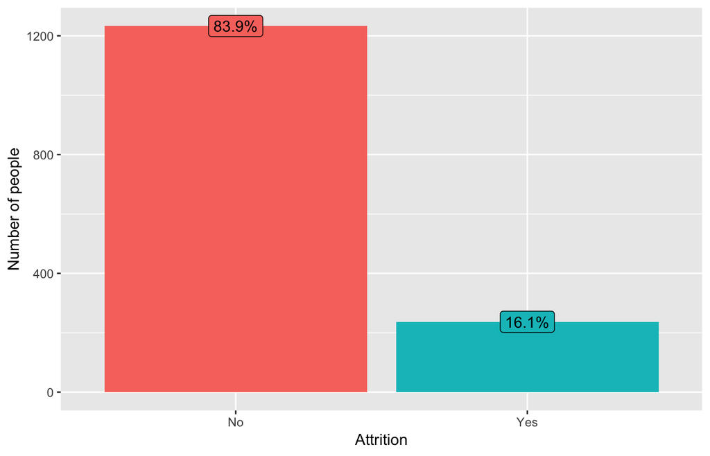

```r
foo <- ibm %>%
  group_by(Attrition) %>%
  count()

foo %>%
  mutate(percentage = str_c(as.character(round(n / sum(foo$n) * 100, 1)), "%")) %>%
  ggplot(aes(Attrition, n, fill = Attrition)) +
  geom_col() +
  geom_label(aes(label = percentage), position = position_dodge(width = 1)) +
  labs(y = "Number of people") +
  theme(legend.position = "none")
```

Attritionが約16%ほど存在することがわかりました。何年分のデータを利用しているかわかりませんが、1年間だとすると多いような感覚ですね。

## 3.2 AgeとAttritionの関係

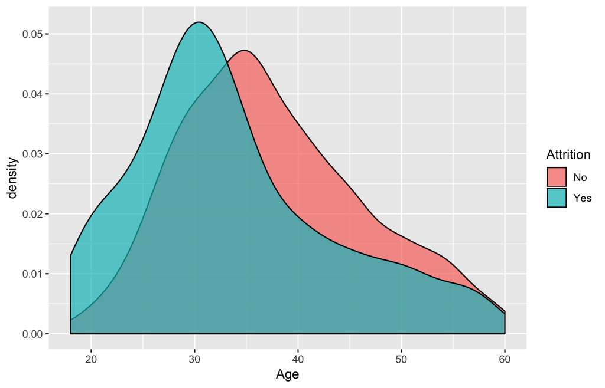

```r
ggplot(ibm, aes(Age, fill = Attrition)) +
  geom_density(alpha = 0.7)
```

年齢に関して見ると、若い方のAttritionが多い傾向にあるようです。

## 3.3 MonthlyIncome, RateとAttritionはどのような関係にあるのか？

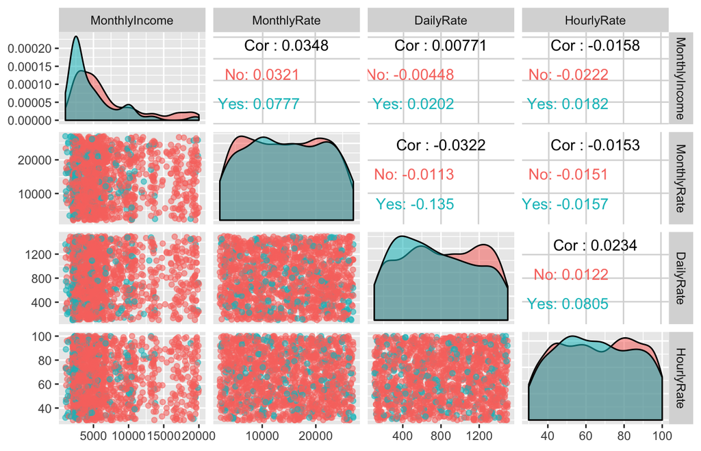

```r
ggpairs(ibm, mapping = aes(colour = Attrition, alpha = 0.7), columns = c("MonthlyIncome", "MonthlyRate", "DailyRate", "HourlyRate"))
```

ここからわかることは以下2つかと思います。

- IncomeとRateは特に関係はない
  - 架空のデータセットなのでこれ以上はわかりかねます
- 退職される方はMonthlyIncomeが低い人が多い傾向にある

確証を得るためにAttrion別にMontlyIncomeを比較してみます。

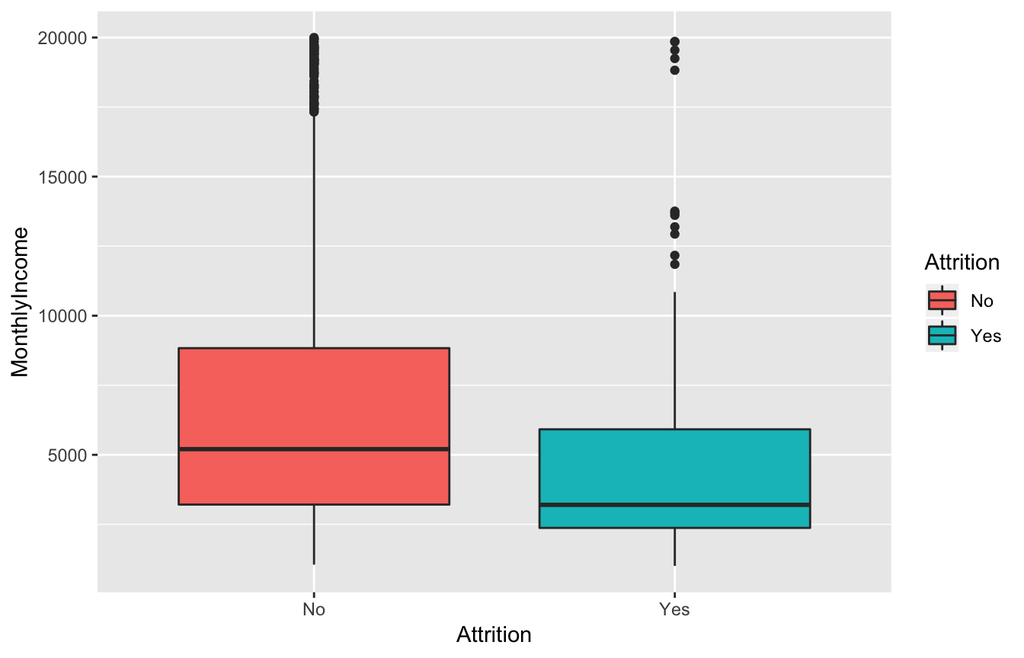

```r
ggplot(ibm, aes(Attrition, MonthlyIncome, fill = Attrition)) +
  geom_boxplot()
```

やはりIncomeが低い人が退職する傾向にありそうです。しかしながら、一部Incomeが高い人も退職しており、なにか別の変数の影響も考えられそうです。

### 3.3.1 JobLevelとMonthlyIncome

一般的にjob levelが高ければincomeも高いと考えられます。なのでjob level, incomeそしてAttritionの関係を見ていきたいと思います。

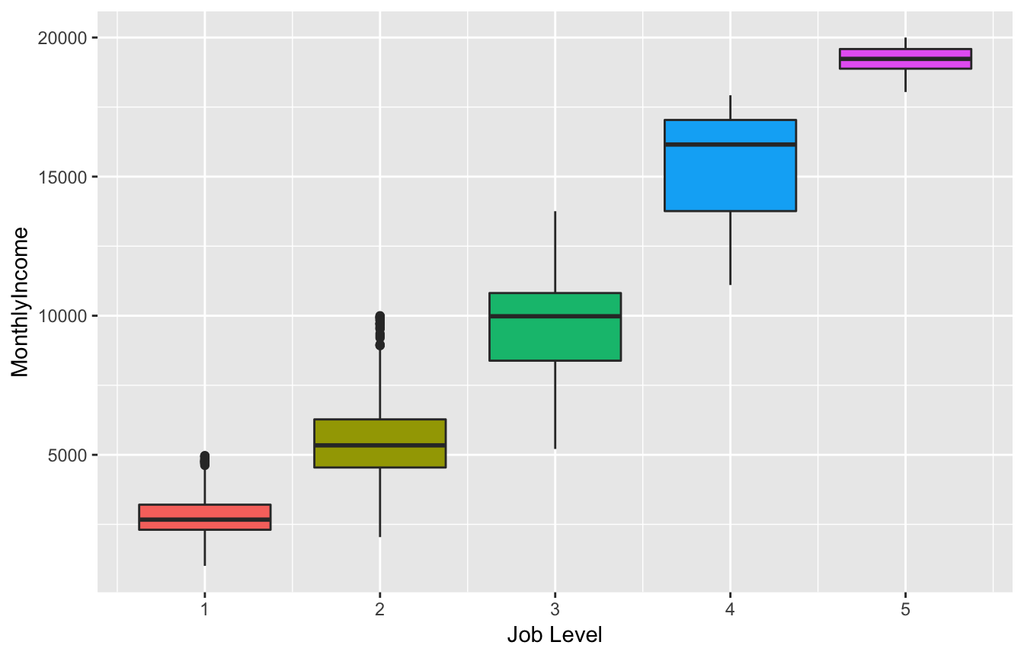

```r
ggplot(ibm, aes(JobLevel, MonthlyIncome, group = JobLevel)) +
  geom_boxplot(aes(fill = factor(JobLevel))) +
  labs(x = "Job Level") +
  theme(legend.position = "none")
```

Job Levelに応じてIncomeが右肩上がりになることは確実なようです。 ではJob LevelごとのAttritionの割合はどうでしょうか

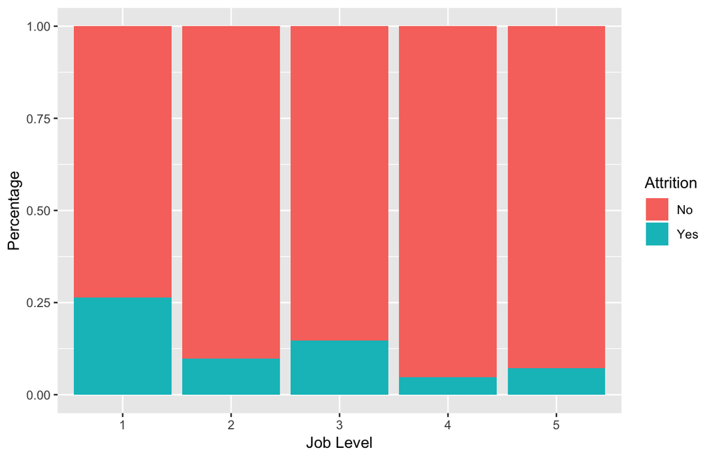

```r
ggplot(ibm, aes(factor(JobLevel), fill = Attrition)) +
  geom_bar(position = "fill") +
  labs(x = "Job Level", y = "Percentage")
```

右肩下がりでAttritionが減るかと思いきやそうではなさそうです。これもまた何か別の変数の影響が考えられそうです。